# CP05 - Colgate vs. Crest

Diego Senso González

23/11/2020

## Objetivo

El objetivo del presente informe es predecir las ventas de Colgate y Crest de las 16 semanas del año 1963. Para ello, se incluirá un modelo ARIMA, se detectarán outliers y se realizará un modelo de intervención, entre otros.

Cargamos las librerías necesarias.

## Carga de los datos y tratamiento y limpieza

No existen ni NAs ni duplicados en el dataframe.

## Tratamiento y visualización del dataframe

Antes de pasar al tratamiento, podemos realizar una primera observación numérica de los datos de ambas empresas gracias a la función “skim”.

Data summary

| Name | rawData[, 3:4] |
| --- | --- |
| Number of rows | 276 |
| Number of columns | 2 |
| _______________________ |  |
| Column type frequency: |  |
| numeric | 2 |
| ________________________ |  |
| Group variables | None |

**Variable type: numeric**

| skim_variable | n_missing | complete_rate | mean | sd | p0 | p25 | p50 | p75 | p100 | hist |
| --- | --- | --- | --- | --- | --- | --- | --- | --- | --- | --- |
| Crest | 0 | 1 | 0.26 | 0.13 | 0.05 | 0.13 | 0.25 | 0.37 | 0.53 | ▇▅▃▇▂ |
| Colgate | 0 | 1 | 0.31 | 0.07 | 0.16 | 0.26 | 0.31 | 0.36 | 0.50 | ▂▇▇▅▁ |

A pesar de que la media más alta la tiene Colgate, el punto máximo del periodo recogido es registrado por Crest.

A continuación, se extraen los datos de cada una de las dos empresas. Se crea un vector de fechas que va entre los periodos de los cuales hay datos. Dicho vector irá por semanas, ya que las ventas se ofrecen de forma semanal. Se crean los objetos xts y se ordenan los datos por fecha. Posteriormente, se pasa a formato zoo.

Visualizamos los datos de ambas empresas:

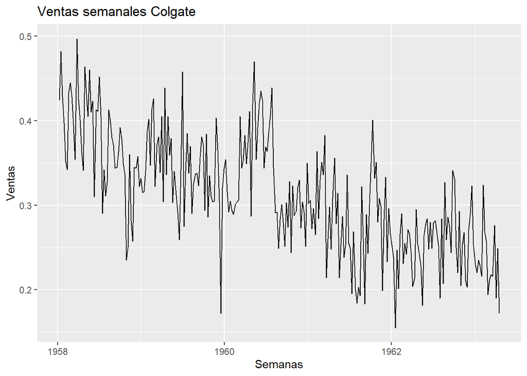

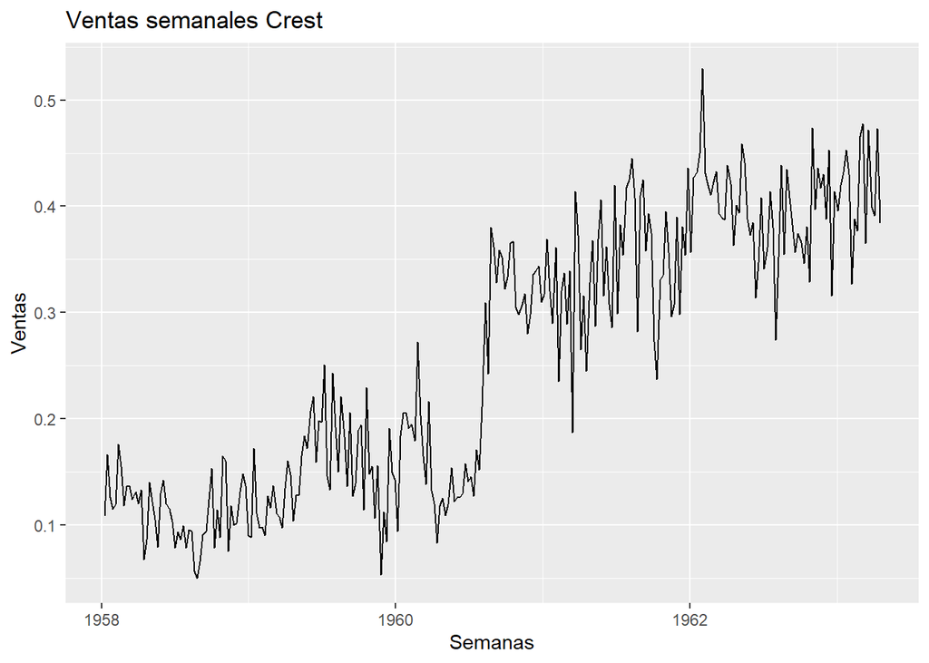

En el gráfico se puede observar el comportamiento de cada una de las dos series. Salta a la vista el suceso del 1 de agosto de 1960, en el que la American Dental Association consideraba a Crest como bueno para la higiene dental. En la gráfica de Colgate, se percibe un claro descenso al afectarle directamente esta noticia, mientras que en Crest se destaca un claro aumento de sus ventas.

## Modelos ARIMA

Para estimar el modelo ARIMA creamos los conjuntos de train o entrenamiento de cada empresa. La fecha se elige para dejar fuera las 16 últimas semanas, que son las que se trata de predecir y que serán la parte de test.

Ahora se representan los resultados de ambos modelos.

```
## Series: trainColgate
## ARIMA(0,1,1)
##
## Coefficients:
##           ma1
##       -0.7586
## s.e.   0.0467
##
## sigma^2 estimated as 0.002312:  log likelihood=418.57
## AIC=-833.14   AICc=-833.09   BIC=-826.02
##
## Training set error measures:
##                        ME       RMSE       MAE       MPE     MAPE      MASE
## Training set -0.002603891 0.04790139 0.0377572 -3.050317 12.79113 0.1188498
##                    ACF1
## Training set 0.05192333
```

```
## Series: trainCrest
## ARIMA(0,1,1)
##
## Coefficients:
##           ma1
##       -0.6494
## s.e.   0.0448
##
## sigma^2 estimated as 0.002054:  log likelihood=434.08
## AIC=-864.15   AICc=-864.1   BIC=-857.04
##
## Training set error measures:
##                       ME       RMSE        MAE       MPE     MAPE      MASE
## Training set 0.003018071 0.04514444 0.03445351 -2.924537 17.27068 0.1405405
##                     ACF1
## Training set -0.04605961
```

Tras esto, se pueden visualizar los errores de ambos modelos. Es especialmente relevante el gráfico de ACF, que expondrá si los residuos son ruido blanco, como es deseable.

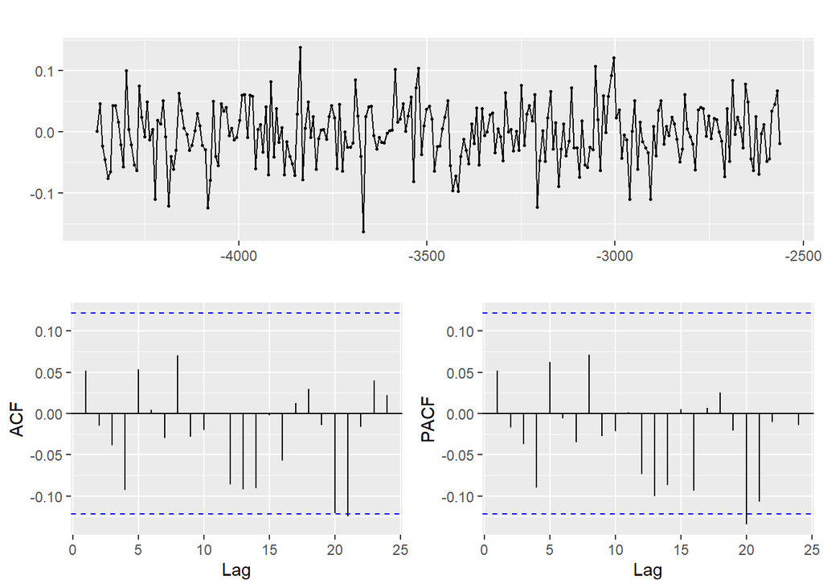

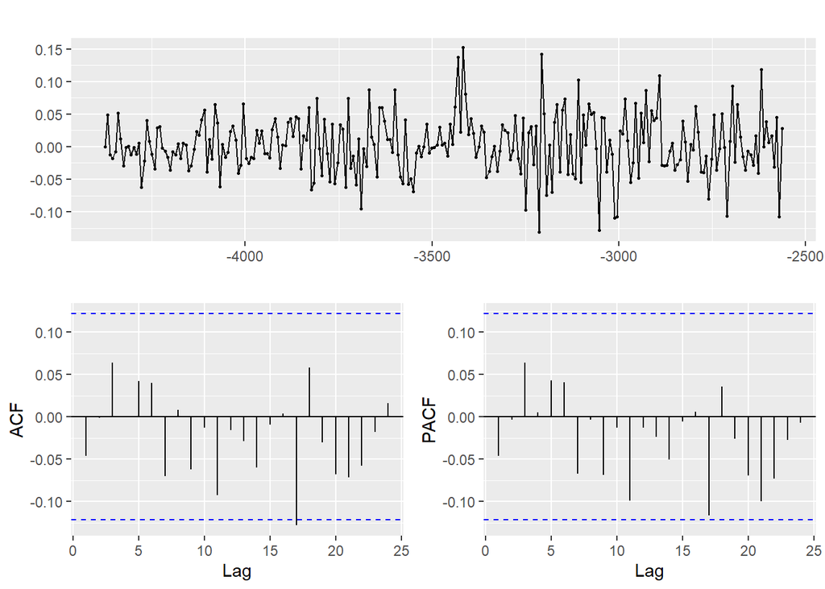

## Outliers

Los outliers puede ser aditivos (si afectan a la serie temporal) o innovativos (si afectan al error). Habrá que buscar los dos para las dos series temporales que tenemos. Para ello, se tratan de detectar sobre los modelos ARIMA previamente definidos.

```
## [1] "No AO detected"
```

```
## [1] "No IO detected"
```

```
##               [,1]       [,2]       [,3]
## ind     135.000000 136.000000 138.000000
## lambda2   3.918954   4.372891   4.005427
```

```
## [1] "No IO detected"
```

A juzgar por lo resultados, existen outliers aditivos de la serie de ventas de Crest en sus observaciones 135, 136 y 138. Son outliers que afectan a la serie temporal. Por ello, habrá que tratarlos siguiendo el modelo de intervención.

## Modelo de intervención

Al ser un outlier aditivo, habrá que tratarlo con un análisis de intervención de tipo escalón (E911). Además, se incluyen los outliers también de las obs 136 y 138. Se define un modelo ARIMAX con todo ello.

```
##
## Call:
## arimax(x = trainCrest, order = c(0, 1, 1), xreg = data.frame(E911 = 1 * (seq(trainCrest) ==
##     136), E911 = 1 * (seq(trainCrest) == 138)), method = "ML", xtransf = data.frame(E911 = 1 *
##     (seq(trainCrest) >= 135)), transfer = list(c(0, 0)))
##
## Coefficients:
##           ma1    E911  E911.1  E911-MA0
##       -0.7445  0.0225  0.0768    0.1336
## s.e.   0.0493  0.0432  0.0414    0.0327
##
## sigma^2 estimated as 0.001877:  log likelihood = 445.09,  aic = -882.18
```

El dato -0.7445 habla de cómo ha cambiado la media móvil tras el tratamiento.

## Modelo de función de transferencia

Para realizar la función de transferencia se considera la observación 135 como el corte a partir del cual observar diferencias entre las series. Se crea un primer lugar un objeto de cada serie con los datos de ventas, y luego otro con las diferencias de cada semana respecto a la anterior.

Se crea un modelo ARIMAX en el que se relaciona la serie temporal de Colgate con respecto a la de Crest.

```
##
## Call:
## arimax(x = colgate_134, order = c(0, 1, 1), include.mean = TRUE, method = "ML",
##     xtransf = crest_134, transfer = list(c(0, 15)))
##
## Coefficients:
##           ma1  xCrest.Close-MA0  xCrest.Close-MA1  xCrest.Close-MA2
##       -0.8293           -0.5024           -0.0371           -0.0354
## s.e.   0.0398            0.0576            0.0579            0.0589
##       xCrest.Close-MA3  xCrest.Close-MA4  xCrest.Close-MA5  xCrest.Close-MA6
##                -0.0249            0.0933           -0.0282            0.0789
## s.e.            0.0596            0.0597            0.0597            0.0598
##       xCrest.Close-MA7  xCrest.Close-MA8  xCrest.Close-MA9  xCrest.Close-MA10
##                 0.0208           -0.0124           -0.0124            -0.0497
## s.e.            0.0600            0.0600            0.0607             0.0608
##       xCrest.Close-MA11  xCrest.Close-MA12  xCrest.Close-MA13
##                  0.0297             0.0019             0.0735
## s.e.             0.0607             0.0607             0.0599
##       xCrest.Close-MA14  xCrest.Close-MA15
##                  0.0195            -0.0464
## s.e.             0.0597             0.0589
##
## sigma^2 estimated as 0.001661:  log likelihood = 434.03,  aic = -834.06
##
## Training set error measures:
##                        ME       RMSE        MAE       MPE    MAPE      MASE
## Training set 3.136974e-05 0.04067314 0.03127273 -1.670614 10.5805 0.6701115
##                    ACF1
## Training set 0.07974374
```

Se grafican los residuos de este modelo. Como se puede observar, son ruido blanco.

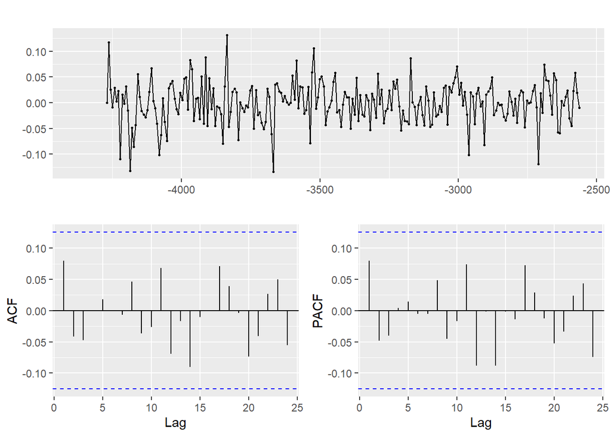

Ahora se repite el proceso pero el modelo ARIMAX se define con el vector de valores que contiene las diferencias de cada empresa.

```
##
## Call:
## arimax(x = colgate_134_D, order = c(0, 1, 1), include.mean = TRUE, method = "ML",
##     xtransf = crest_134_D, transfer = list(c(1, 3)))
##
## Coefficients:
##           ma1  xCrest.Close-AR1  xCrest.Close-MA0  xCrest.Close-MA1
##       -1.0000           -0.6944           -0.4875           -0.3668
## s.e.   0.0097            0.2122            0.0716            0.1504
##       xCrest.Close-MA2  xCrest.Close-MA3
##                -0.0774           -0.1140
## s.e.            0.1199            0.0772
##
## sigma^2 estimated as 0.002732:  log likelihood = 388,  aic = -764
##
## Training set error measures:
##                        ME       RMSE        MAE      MPE     MAPE      MASE
## Training set 0.0004530117 0.05216485 0.04001218 81.81399 160.2699 0.5085793
##                    ACF1
## Training set -0.4096217
```

Se grafican también lo residuos de este modelo:

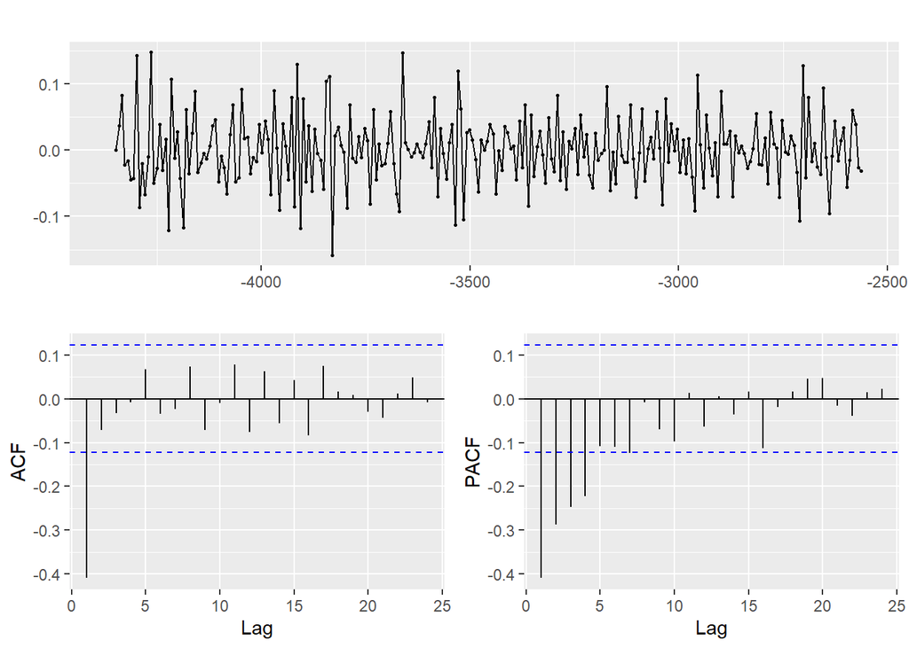

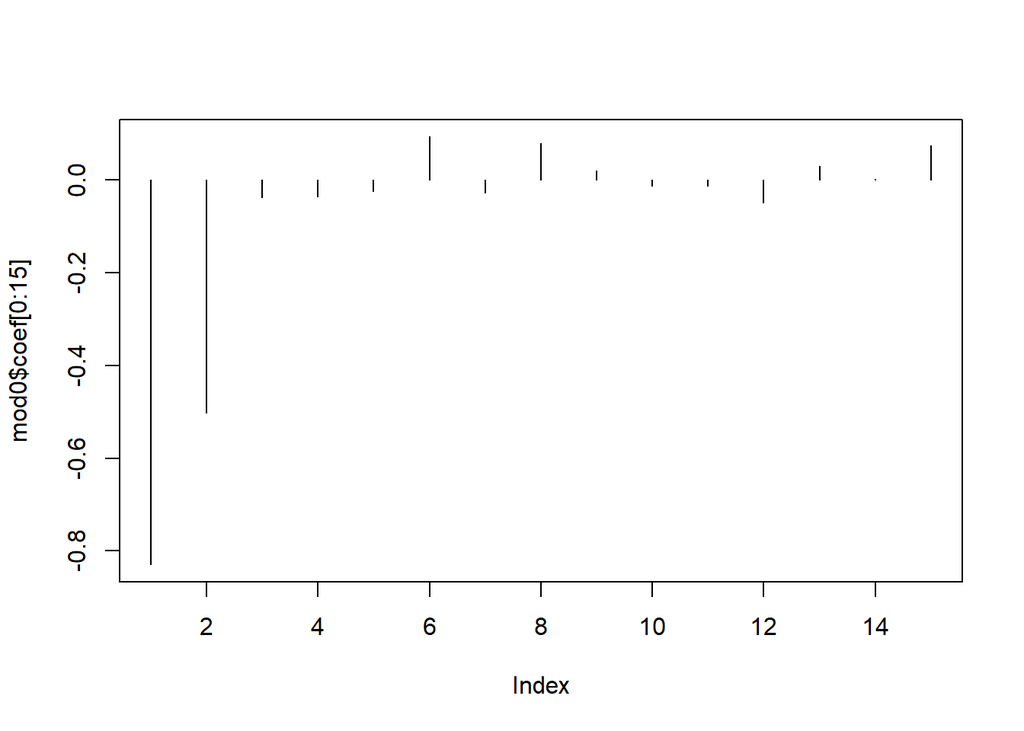

Observando la última gráfica, cabría considerar el valor de S=2 dado que la caída parece complicada, pues parece que la hay y no es exponencial.

```
##
## Call:
## arimax(x = colgate_134_D, order = c(0, 1, 1), include.mean = TRUE, fixed = c(NA,
##     NA, 0, 0, 0, NA), method = "ML", xtransf = crest_134_D, transfer = list(c(1,
##     3)))
##
## Coefficients:
##           ma1  xCrest.Close-AR1  xCrest.Close-MA0  xCrest.Close-MA1
##       -1.0000           -0.5981                 0                 0
## s.e.   0.0097            0.2037                 0                 0
##       xCrest.Close-MA2  xCrest.Close-MA3
##                      0           -0.0855
## s.e.                 0            0.0486
##
## sigma^2 estimated as 0.003417:  log likelihood = 359.45,  aic = -712.9
##
## Training set error measures:
##                        ME       RMSE        MAE      MPE     MAPE      MASE
## Training set 0.0002523355 0.05834496 0.04562985 87.70553 108.5678 0.5799833
##                    ACF1
## Training set -0.4385192
```

Se han seleccionado para ser estimados una serie de parámetros, mientras que en los otros se les ha dado el valor de cero. De esta forma, estima la media móvil y los parámetros marcados con el valor NA. Tanto de los resultados de este último modelo como de los anteriores ARIMAX, se concluye que dado que los coeficientes presentan valores negativos, las ventas de Crest tienen un efecto negativo sobre las de Colgate. Esto es debido al suceso que se comentaba al comienzo, cuando la ADA recomendó la marca Crest.

## Predicción

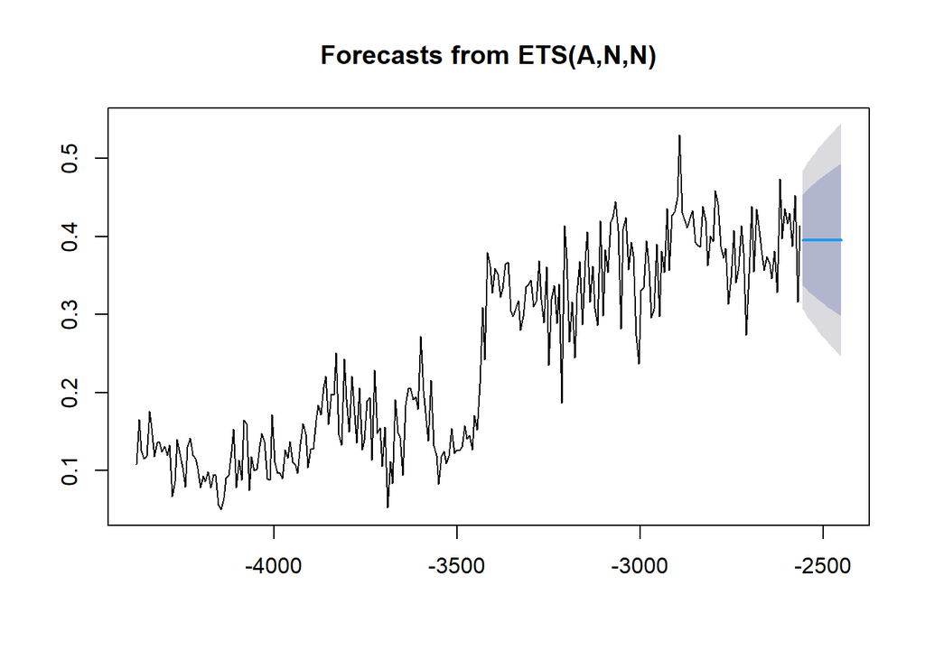

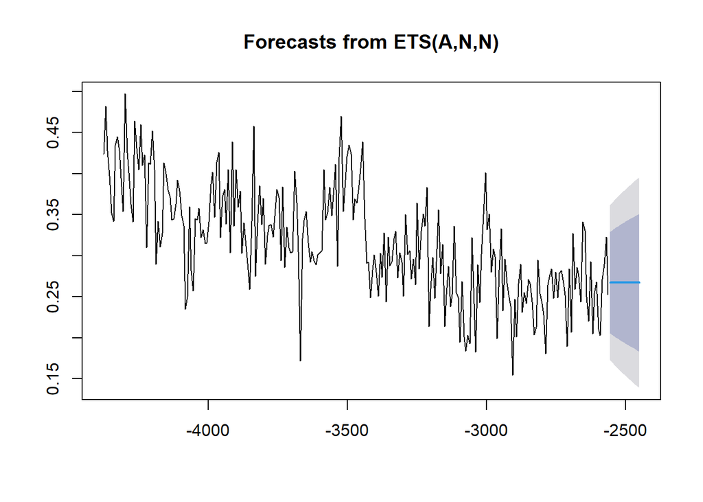